# due 12/18/2023

# Determining Trade Union Status - A Final Project

```python
import pandas as pd
from sklearn.model_selection import train_test_split
from sklearn.preprocessing import StandardScaler, OneHotEncoder
from sklearn.compose import ColumnTransformer
from sklearn.pipeline import Pipeline
from sklearn.linear_model import LogisticRegression
from sklearn.metrics import classification_report, accuracy_score
import seaborn as sns
import matplotlib.pyplot as plt
from sklearn.decomposition import PCA
from sklearn.preprocessing import StandardScaler
from sklearn.tree import DecisionTreeClassifier, plot_tree
from sklearn.metrics import accuracy_score, classification_report, confusion_matrix
from sklearn.svm import SVC
from sklearn.ensemble import RandomForestClassifier
from sklearn.preprocessing import LabelEncoder
```

```python
# Load the dataset
file_path = r'C:\Users\aldul\Downloads\DSCI_508\final capstone\Shahal -TRAIN.xlsx'
df = pd.read_excel(file_path)
```

```python
df.isna().sum()
```

```
ID                  0
gender              0
Management          0
USAcitizen          0
Married             0
MonthsInUnion       0
ContinuingEd        0
StateOfResidence    0
Connectivity        0
FeatureA            0
FeatureB            0
FeatureC            0
FeatureD            0
FeatureE            0
FeatureF            0
DuesFrequency       0
PaperlessBilling    0
PaymentMethod       0
MonthlyDues         0
TotalDues           0
LeftUnion           0
dtype: int64
```

```python
nan_count_per_column = df.isnull().sum()

total_nan_count = df.isnull().sum().sum()

# Display columns with NaN values and their counts
print("Columns with NaN values and their counts:")
print(nan_count_per_column[nan_count_per_column > 0])

print("\nTotal number of NaN values in the DataFrame:", total_nan_count)
```

```
Columns with NaN values and their counts:
Series([], dtype: int64)

Total number of NaN values in the DataFrame: 0
```

```python
# Explore the dataset
print(df.head())
```

```
               ID  gender  Management USAcitizen Married  MonthsInUnion  \
0  Shahal 1-17338    Male           0         No     Yes             13
1  Shahal 2-16757    Male           0         No      No              1
2  Shahal 3-13479    Male           0        Yes     Yes             63
3  Shahal 4-14315  Female           0         No      No             39
4  Shahal 5-19997    Male           0         No      No             34

  ContinuingEd StateOfResidence Connectivity   FeatureA  ...   FeatureC  \
0          Yes               MO          DSL        Yes  ...         No
1          Yes               MO           No  Maryville  ...  Maryville
2          Yes               IL  Fiber optic         No  ...         No
3           No               MO          DSL         No  ...        Yes
4          Yes               MO          DSL        Yes  ...        Yes

    FeatureD   FeatureE   FeatureF   DuesFrequency PaperlessBilling  \
0         No         No         No  Month-to-month              Yes
1  Maryville  Maryville  Maryville  Month-to-month               No
2         No         No        Yes        One year              Yes
3         No        Yes        Yes  Month-to-month              Yes
4         No         No         No        One year               No

             PaymentMethod MonthlyDues  TotalDues LeftUnion
0  Credit card (automatic)       52.10     670.65        No
1             Mailed check       20.10       20.1       Yes
2         Electronic check       91.35     5764.7        No
3         Electronic check       50.75     2011.4       Yes
4             Mailed check       56.95     1889.5        No

[5 rows x 21 columns]
```

```python
print(df.info())
```

```
<class 'pandas.core.frame.DataFrame'>
RangeIndex: 1999 entries, 0 to 1998
Data columns (total 21 columns):
 #   Column            Non-Null Count  Dtype
---  ------            --------------  -----
 0   ID                1999 non-null   object
 1   gender            1999 non-null   object
 2   Management        1999 non-null   int64
 3   USAcitizen        1999 non-null   object
 4   Married           1999 non-null   object
 5   MonthsInUnion     1999 non-null   int64
 6   ContinuingEd      1999 non-null   object
 7   StateOfResidence  1999 non-null   object
 8   Connectivity      1999 non-null   object
 9   FeatureA          1999 non-null   object
 10  FeatureB          1999 non-null   object
 11  FeatureC          1999 non-null   object
 12  FeatureD          1999 non-null   object
 13  FeatureE          1999 non-null   object
 14  FeatureF          1999 non-null   object
 15  DuesFrequency     1999 non-null   object
 16  PaperlessBilling  1999 non-null   object
 17  PaymentMethod     1999 non-null   object
 18  MonthlyDues       1999 non-null   float64
 19  TotalDues         1999 non-null   object
 20  LeftUnion         1999 non-null   object
dtypes: float64(1), int64(2), object(18)
memory usage: 328.1+ KB
None
```

```python
# Display column names in a more readable way
column_names = df.columns.tolist()
print(column_names)
```

```
['ID', 'gender', 'Management', 'USAcitizen', 'Married', 'MonthsInUnion', 'ContinuingEd', 'StateOfResidence', 'Connectivity', 'FeatureA', 'FeatureB', 'FeatureC', 'FeatureD', 'FeatureE', 'FeatureF', 'DuesFrequency', 'PaperlessBilling', 'PaymentMethod', 'MonthlyDues', 'TotalDues', 'LeftUnion']
```

```python
# Convert categorical features to numeric using one-hot encoding
df['TotalDues'] = pd.to_numeric(df['TotalDues'], errors='coerce')
```

```python
# Handle missing values
df = df.dropna(subset=['TotalDues'])
```

```python
numeric_columns = ['MonthsInUnion', 'MonthlyDues', 'TotalDues']
```

```python
# Normalize numerical features
scaler = StandardScaler()
df[numeric_columns] = scaler.fit_transform(df[numeric_columns])
```

```python
# Feature Selection
features = ['gender', 'Management', 'MonthsInUnion', 'MonthlyDues', 'TotalDues', 'PaperlessBilling', 'PaymentMethod']
target = 'LeftUnion'

X = df[features]
y = df[target]
```

```python
# Split the Data into Training and Testing Sets
X_train, X_test, y_train, y_test = train_test_split(X, y, test_size=0.2, random_state=42)
```

```python
print("X_train shape:", X_train.shape)
print("X_test shape:", X_test.shape)
print("y_train shape:", y_train.shape)
print("y_test shape:", y_test.shape)
```

```
X_train shape: (1595, 7)
X_test shape: (399, 7)
y_train shape: (1595,)
y_test shape: (399,)
```

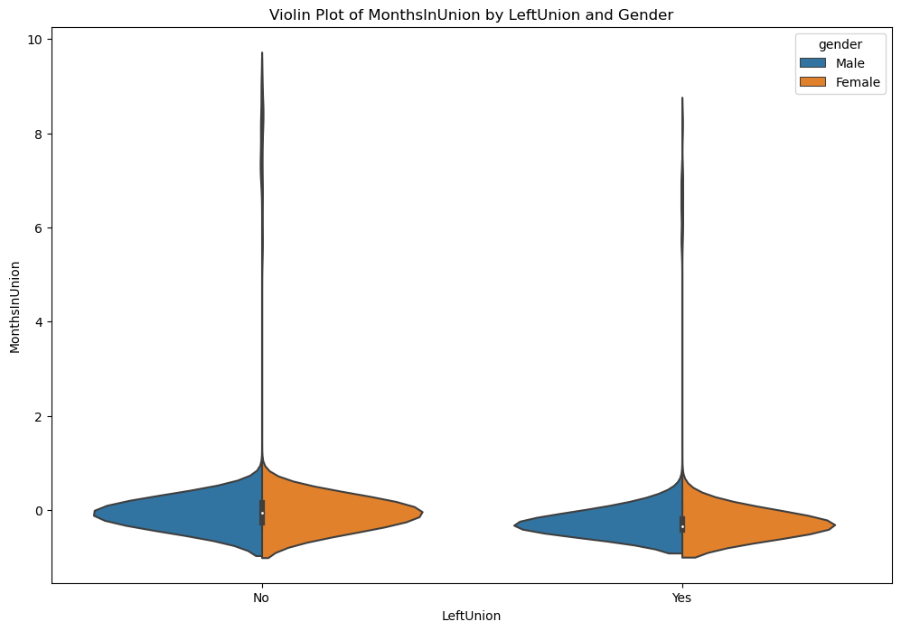

```python
# Violin plot
data_for_violin = df[features + [target]]
plt.figure(figsize=(12, 8))
sns.violinplot(x=target, y='MonthsInUnion', data=data_for_violin, hue='gender', split=True)
plt.title('Violin Plot of MonthsInUnion by LeftUnion and Gender')
plt.show()
```

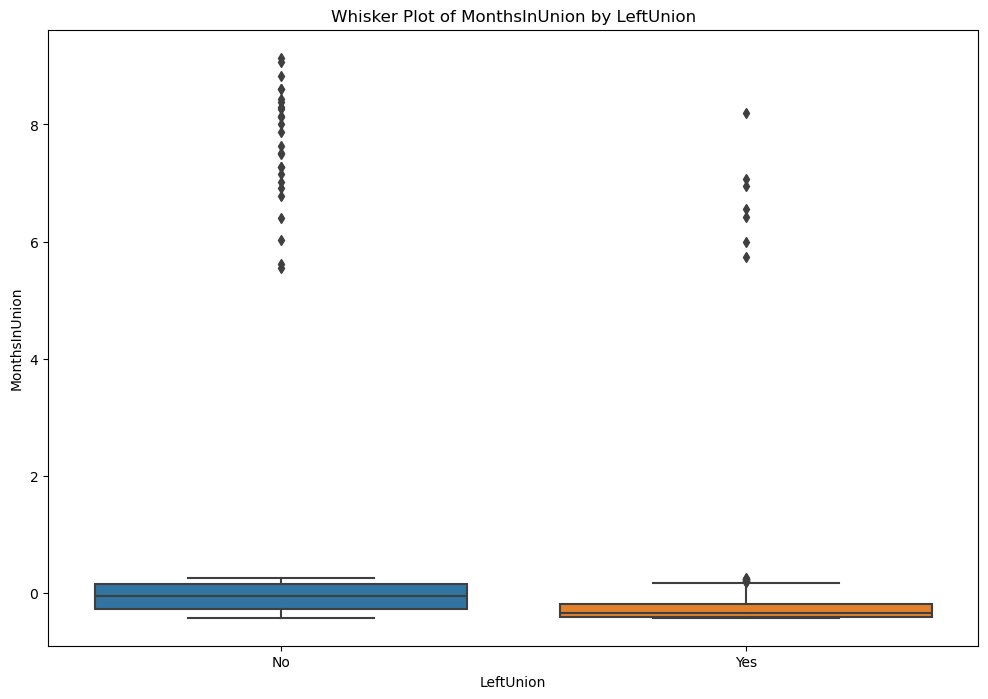

```python
# Create a box plot
plt.figure(figsize=(12, 8))
sns.boxplot(x='LeftUnion', y='MonthsInUnion', data=df)
plt.title('Whisker Plot of MonthsInUnion by LeftUnion')
plt.show()
```

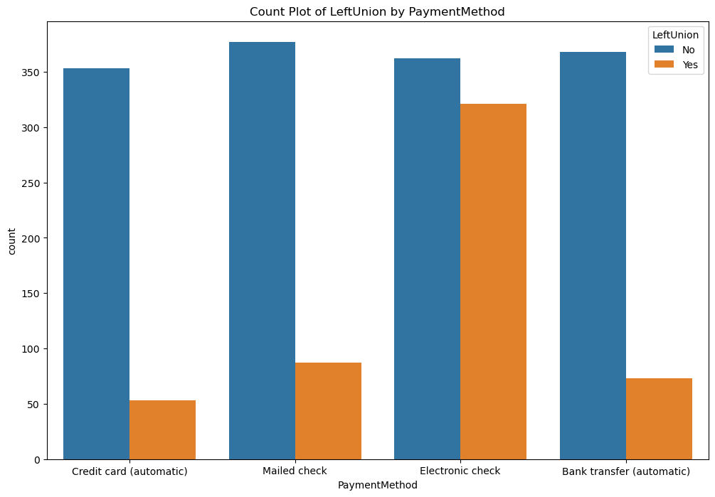

```python
plt.figure(figsize=(12, 8))
sns.countplot(x='PaymentMethod', hue='LeftUnion', data=df)
plt.title('Count Plot of LeftUnion by PaymentMethod')
plt.show()
```

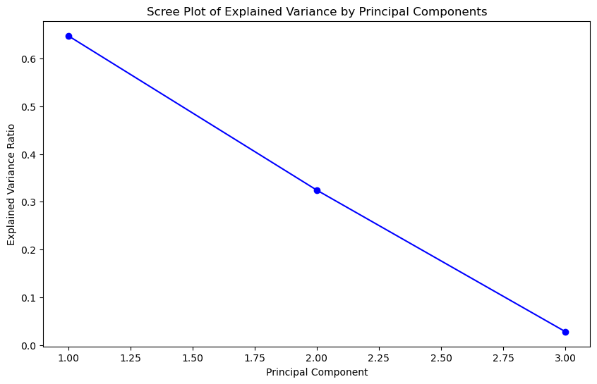

```python
# Scree plot
features = ['MonthsInUnion', 'MonthlyDues', 'TotalDues']
scaler = StandardScaler()
scaled_features = scaler.fit_transform(df[features])
pca = PCA()
pca.fit(scaled_features)
plt.figure(figsize=(10, 6))
plt.plot(range(1, len(pca.explained_variance_ratio_) + 1), pca.explained_variance_ratio_, marker='o', linestyle='-', color='b')
plt.title('Scree Plot of Explained Variance by Principal Components')
plt.xlabel('Principal Component')
plt.ylabel('Explained Variance Ratio')
plt.show()
```

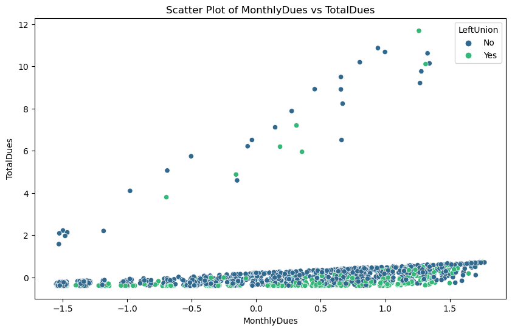

```python
#Scatter plot of the data
feature_x = 'MonthlyDues'
feature_y = 'TotalDues'
plt.figure(figsize=(10, 6))
sns.scatterplot(x=feature_x, y=feature_y, data=df, hue='LeftUnion', palette='viridis')
plt.title('Scatter Plot of MonthlyDues vs TotalDues')
plt.xlabel(feature_x)
plt.ylabel(feature_y)
plt.show()
```

[output not shown]

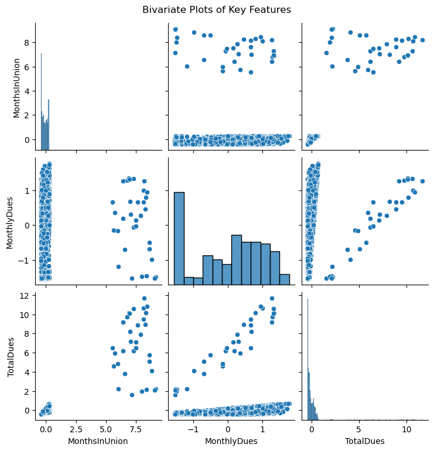

```python
#Bivariate plots between key feature
key_features = ['MonthsInUnion', 'MonthlyDues', 'TotalDues']
sns.pairplot(df[key_features])
plt.suptitle('Bivariate Plots of Key Features', y=1.02)
plt.show()
```

```python
# Select numeric columns
numeric_columns_train = X_train.select_dtypes(include=['number']).columns

# Calculate the correlation matrix for numeric columns in X_train
correlation_matrix_train = X_train[numeric_columns_train].corr()

# Display the correlation matrix
print(correlation_matrix_train)
```

```
               Management  MonthsInUnion  MonthlyDues  TotalDues
Management       1.000000       0.005017     0.211744   0.039685
MonthsInUnion    0.005017       1.000000     0.067208   0.912937
MonthlyDues      0.211744       0.067208     1.000000   0.244942
TotalDues        0.039685       0.912937     0.244942   1.000000
```

```
Accuracy: 0.7192982456140351
Confusion Matrix:
[[224  53]
 [ 59  63]]
Classification Report:
              precision    recall  f1-score   support

          No       0.79      0.81      0.80       277
         Yes       0.54      0.52      0.53       122

    accuracy                           0.72       399
   macro avg       0.67      0.66      0.66       399
weighted avg       0.72      0.72      0.72       399
```

[output not shown]

[output cut: 18 more lines]

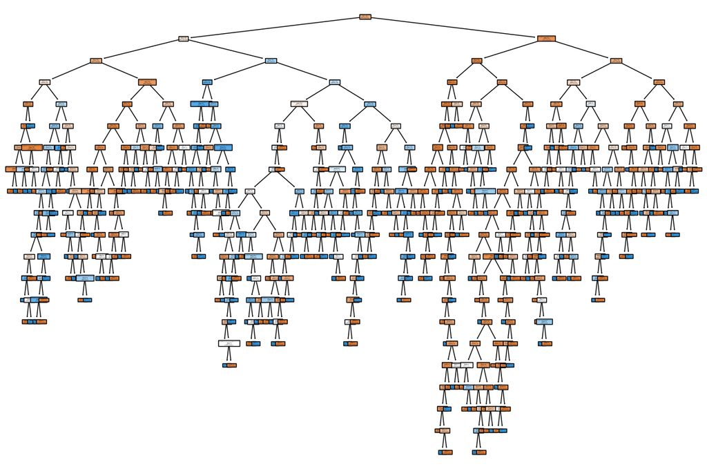

```python
# predict UDSU loyalty Decision Tree
features = ['MonthsInUnion', 'MonthlyDues', 'TotalDues', 'gender', 'Management', 'PaperlessBilling', 'PaymentMethod']
target = 'LeftUnion'

X = df[features]
y = df[target]

# Convert categorical variables to numerical format using label encoding
X = pd.get_dummies(X, columns=['gender', 'Management', 'PaperlessBilling', 'PaymentMethod'], drop_first=True)

# Split the data into training and testing sets
X_train, X_test, y_train, y_test = train_test_split(X, y, test_size=0.2, random_state=42)

# Create and train the Decision Tree model
model = DecisionTreeClassifier(random_state=42)
model.fit(X_train, y_train)

# Make predictions on the test set
y_pred = model.predict(X_test)

# Evaluate the model
accuracy = accuracy_score(y_test, y_pred)
conf_matrix = confusion_matrix(y_test, y_pred)
classification_rep = classification_report(y_test, y_pred)

print(f'Accuracy: {accuracy}')
print(f'Confusion Matrix:\n{conf_matrix}')
print(f'Classification Report:\n{classification_rep}')

# Plot the Decision Tree
plt.figure(figsize=(15, 10))
plot_tree(model, filled=True, feature_names=X.columns, class_names=['Not LeftUnion', 'LeftUnion'])
plt.show()
```

```python
# Define predictor variables (features) and target variable
features = ['MonthsInUnion', 'MonthlyDues', 'TotalDues', 'gender', 'Management', 'PaperlessBilling', 'PaymentMethod']
target = 'LeftUnion'

X = df[features]
y = df[target]

# Convert categorical variables to numerical format using one-hot encoding
X = pd.get_dummies(X, columns=['gender', 'Management', 'PaperlessBilling', 'PaymentMethod'], drop_first=True)

# Split the data into training and testing sets
X_train, X_test, y_train, y_test = train_test_split(X, y, test_size=0.2, random_state=42)

# Standardize numerical features
scaler = StandardScaler()
X_train_scaled = scaler.fit_transform(X_train)
X_test_scaled = scaler.transform(X_test)

# Create and train the Support Vector Machine model
model = SVC(random_state=42)
model.fit(X_train_scaled, y_train)

# Make predictions on the test set
y_pred = model.predict(X_test_scaled)

# Evaluate the model
accuracy = accuracy_score(y_test, y_pred)
conf_matrix = confusion_matrix(y_test, y_pred)
classification_rep = classification_report(y_test, y_pred)

print(f'Accuracy: {accuracy}')
print(f'Confusion Matrix:\n{conf_matrix}')
print(f'Classification Report:\n{classification_rep}')
```

```
Accuracy: 0.7293233082706767
Confusion Matrix:
[[250  27]
 [ 81  41]]
Classification Report:
              precision    recall  f1-score   support

          No       0.76      0.90      0.82       277
         Yes       0.60      0.34      0.43       122

    accuracy                           0.73       399
   macro avg       0.68      0.62      0.63       399
weighted avg       0.71      0.73      0.70       399
```

[output not shown]

[output cut: 20 more lines]

[output not shown]

```
Accuracy: 0.7568922305764411
Confusion Matrix:
[[249  28]
 [ 69  53]]
Classification Report:
              precision    recall  f1-score   support

          No       0.78      0.90      0.84       277
         Yes       0.65      0.43      0.52       122

    accuracy                           0.76       399
   macro avg       0.72      0.67      0.68       399
weighted avg       0.74      0.76      0.74       399
```

[output not shown]

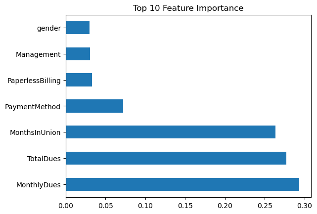

```python
# Define predictor variables (features) and target variable
features = ['MonthsInUnion', 'MonthlyDues', 'TotalDues', 'gender', 'Management', 'PaperlessBilling', 'PaymentMethod']
target = 'LeftUnion'

X = df[features]
y = df[target]

# Label encode categorical variables
le = LabelEncoder()
X['gender'] = le.fit_transform(X['gender'])
X['Management'] = le.fit_transform(X['Management'])
X['PaperlessBilling'] = le.fit_transform(X['PaperlessBilling'])
X['PaymentMethod'] = le.fit_transform(X['PaymentMethod'])

# Split the data into training and testing sets
X_train, X_test, y_train, y_test = train_test_split(X, y, test_size=0.2, random_state=42)

# Create and train the Random Forest model
model = RandomForestClassifier(random_state=42)
model.fit(X_train, y_train)

# Make predictions on the test set
y_pred = model.predict(X_test)

# Evaluate the model
accuracy = accuracy_score(y_test, y_pred)
conf_matrix = confusion_matrix(y_test, y_pred)
classification_rep = classification_report(y_test, y_pred)

print(f'Accuracy: {accuracy}')
print(f'Confusion Matrix:\n{conf_matrix}')
print(f'Classification Report:\n{classification_rep}')

# Feature importance plot
feature_importance = pd.Series(model.feature_importances_, index=features)
feature_importance.nlargest(10).plot(kind='barh')
plt.title('Top 10 Feature Importance')
plt.show()
```

# Comparing your results, to that of an educated guess, explain why you think the results differed?

Some interesting patterns emerge when we delve into the data and analyze how different payment methods are associated with members leaving the union.

Electronic Check Users: Percentage Leaving: Around 47% of members who opt for the "Electronic check" payment method leave the union. Implication: This indicates a higher likelihood of dissatisfaction or issues among those using electronic checks, making them more prone to leaving. Mailed Check Users: Percentage Leaving: The "Mailed check" group follows closely with approximately 19%. Implication: While still significant, this percentage is notably lower than electronic checks, suggesting a comparatively better retention rate. Automatic Payment Methods: Credit Card (Automatic): Roughly 13-17% of members using automatic credit card payments leave the union. Bank Transfer (Automatic): Similar to credit cards, this group also shows a lower percentage, around 16.5%, leaving. Implication: Members who have set up automatic payments through credit cards or bank transfers are less likely to leave than those using checks. What Does This Mean for the Union?

Focus on Electronic Check Issues: The union may want to investigate and address potential issues related to electronic check payments. Members using this method seem more susceptible to leaving, so understanding their concerns could be crucial.

# Describe how you would improve your project if you had more time?